# **Predicting Churn**

Andrew Johns

Churn, loss of customers to competition, is an ongoing problem for all telecom companies as it is more expensive to acquire a new customer than it is to keep existing customers from leaving. The object of this study is to build a model to help identify what customers are prepared to leave and their characteristics. This is a targeted approach to help retain customers that are likely to churn and provide them incentives to stay.

The Churn_Train.csv data set is a collection of customer information with 19 predictors and 1 target variable we are looking to predict. This target variable is “churn” with either a “no” or “yes” value.

## **Necessary Packages**

```r
library(dplyr)
library(tidyr)
library(gam)
library(readr)
library(openxlsx)
library(ggplot2)
library(pROC)
```

## **Data Wrangling**

Prior to creating a model, the data needed to be cleaned. Rows primarily NA values were removed, the remaining NAs were replaced with the median of each column. Then negative values that looked to be input incorrectly, were replaced with the absolute value. Finally, the target variable was turned into a factor to be used in the Confusion Matrix.

```r
Churn_Train <- read_csv("Churn_Train.csv")

#Removed 200 lines that contain a majority of NA values
Churn_Train1 <- as.data.frame(Churn_Train[!is.na(Churn_Train$number_vmail_messages),])

#Replace the remaining Na's with median of the column
Median_Replace = function(x) {
  x <- as.numeric(as.character(x)) #first convert each column into numeric if it is from factor
  x[is.na(x)] = median(x, na.rm=TRUE) #convert the item with NA to median value from the column
  x
}
Churn_AccountLength <- data.frame(Churn_Train1$account_length)
Churn_EveMins <- data.frame(Churn_Train1$total_eve_minutes)
Churn_IntCalls <- data.frame(Churn_Train1$total_intl_calls)

Churn_AL_Clean = data.frame(apply(Churn_AccountLength, 2, Median_Replace))
Churn_EveMins_Clean = data.frame(apply(Churn_EveMins, 2, Median_Replace))
Churn_IntCalls_Clean = data.frame(apply(Churn_IntCalls, 2, Median_Replace))

Churn_Train1[, 2] <- Churn_AL_Clean
Churn_Train1[, 10] <- Churn_EveMins_Clean
Churn_Train1[, 17] <- Churn_IntCalls_Clean

#Turn the negative values in the account_length and number_vmail_messages into positive values
Churn_Train1[, 'account_length'] <- abs(Churn_Train1[, 'account_length'])
Churn_Train1[, 'number_vmail_messages'] <- abs(Churn_Train1[, 'number_vmail_messages'])

#Making the 'churn' column a factor for the confusion matrix
Churn_Train1[, 'churn'] <- as.factor(Churn_Train1[, 'churn'])
```

## **Creating the Model**

Logistic Regression was chosen for this type of model as we are predicting a categorical variable with two outcomes. The model discovers that multiple predictors have significance but the four with the most predictive power are varaibles State, Number of Customer Service Calls, Total Day Charge, and International Plan.

```r
model <- glm(formula = churn ~ ., family = "binomial", data = Churn_Train1)
summary(model)
```

[output not shown]

## **Model Performance**

```
##
## Call:
## roc.default(response = Churn_Train1$churn, predictor = predictions)
##
## Data: predictions in 2676 controls (Churn_Train1$churn no) < 457 cases (Churn_Train1$churn yes).
## Area under the curve: 0.8378
```

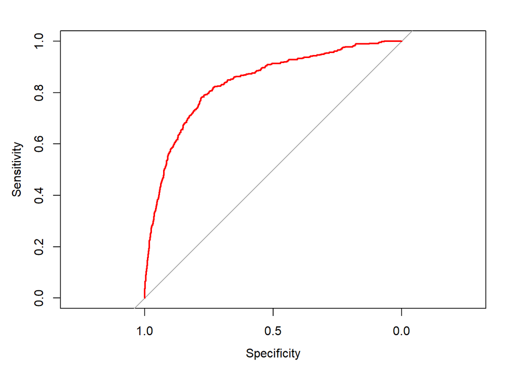

## **Confusion Matrix**

Below is the confusion matrix of “Actual” results of the training data and the “Predicted” results of the model. A threshold of 20% used in the probability variable created with the model predictions. An agressive approach was taken with probability knowing that it is more expensive to spending on those preparing to leave compared to obtaining new business. A higher penalty was placed on the type 1 error of predictions “No” but were actually “Yes”.

```
##          Actual
## Predicted   No  Yes
##       No  2258  146
##       Yes  418  311
```

## **Trend Analysis**

### Churn Ratio by State

Below is a data set created to show the order of states in terms of their churn ratio. This figure is calculated as sum of customers that *will churn* in each state divided by *total* customers in that state. This allows us to see if certain states have a larger portion of the population that is expected to churn relative to that state. California tops the list with 29% of the customers churning and Virginia rounds out the bottom with only 5.8% of the customers churning.

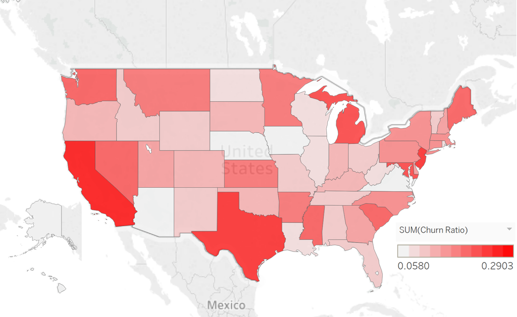

### Customer Service Calls as a Predictor of Churn

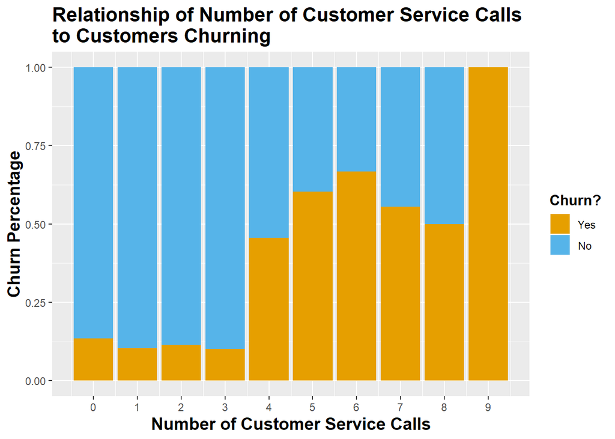

### Density Chart of Total Day Charge

The purpose of the below plot is to divide the customers by the predictor varaible “churn” and create a density histogram based off of total day charge. This allows us to see if either is skewed in a certain direction and we are able to observe the mode of each curve. Those customers not expected to churn produce a relatively normal distribution. It’s with those customers expected to churn we discover a bimodal distribution that is skewed to the left.

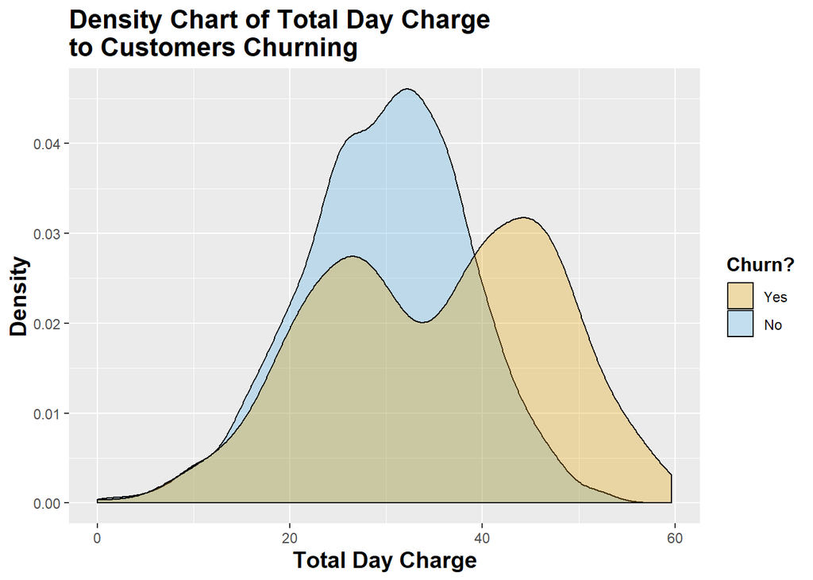

### International Plan’s Affect on Churn

The final trend analysis plot is whether the existance of an International Plan can help predict churn. Below is a bar chart showing those with and without an International Plan and the percentage of those that churn. You can see that customers that have an international plan have a significant increase of the chance of churning, roughly 30% increase.

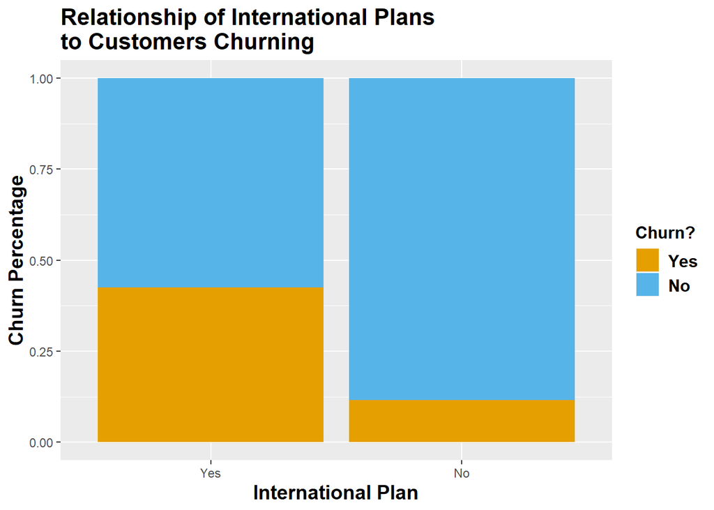